# Discrete random variables

MACS 33001 University of Chicago

$$\newcommand{\E}{\mathrm{E}} \newcommand{\Var}{\mathrm{Var}} \newcommand{\Cov}{\mathrm{Cov}}$$

## Basic concepts

- Random variable
- Function of a random variables
- Averages of interest
- Conditioning
- Independence

## Random variable

- A random process or variable with a numerical outcome
- A random variable $X$ that is a function of the sample space

  $$\begin{eqnarray}
  X:\text{Sample Space} \rightarrow \mathcal{R}
  \end{eqnarray}$$
- Number of incumbents who win
- An indicator whether a country defaults on a loan (1 if a default, 0 otherwise)
- Number of casualties in a war (rather than all possible outcomes)

## Examples of random variables

- Treatment assignment:
  - Suppose we have $3$ units, flipping fair coin ($\frac{1}{2}$) to assign each unit
  - Assign to $T=$Treatment or $C=$control
  - $X$ = Number of units received treatment
  - Defining the function

    $$\begin{equation}
    X = \left \{ \begin{array} {ll}
    0 \text{ if } (C, C, C) \\
    1 \text{ if } (T, C, C) \text{ or } (C, T, C) \text{ or } (C, C, T) \\
    2 \text{ if } (T, T, C) \text{ or } (T, C, T) \text{ or } (C, T, T) \\
    3 \text{ if } (T, T, T)
    \end{array} \right.
    \end{equation}$$
  - In other words:

    $$\begin{eqnarray}
    X( (C, C, C) ) & = & 0 \\
    X( (T, C, C)) & = & 1 \\
    X((T, C, T)) & = & 2 \\
    X((T, T, T)) & = & 3
    \end{eqnarray}$$

## Examples of random variables

- $X$ = Number of Calls into congressional office in some period $p$
  - $X(c) = c$
- Outcome of Election
  - Define $v$ as the proportion of vote the candidate receives
  - Define $X = 1$ if $v>0.50$
  - Define $X = 0$ if $v<0.50$
  - For example, if $v = 0.48$, then $X(v) = 0$
- An indicator whether a country defaults on a loan (1 if a default, 0 otherwise)

## Probability mass functions

- Probability of the values that it can take
- Probability mass function (PMF)

## Probability mass functions

- $P(C, T, C) = P(C)P(T)P(C) = \frac{1}{2}\frac{1}{2}\frac{1}{2} = \frac{1}{8}$
- This applies to all outcomes

  $$\begin{eqnarray}
  p(X = 0) & = & P(C, C, C) = \frac{1}{8}\\
  p(X = 1) & = & P(T, C, C) + P(C, T, C) + P(C, C, T) = \frac{3}{8} \\
  p(X = 2) & = & P(T, T, C) + P(T, C, T) + P(C, T, T) = \frac{3}{8} \\
  p(X = 3) & = & P(T, T, T) = \frac{1}{8}
  \end{eqnarray}$$
- $p(X = a) = 0$, for all $a \notin (0, 1, 2, 3)$

## Probability mass functions

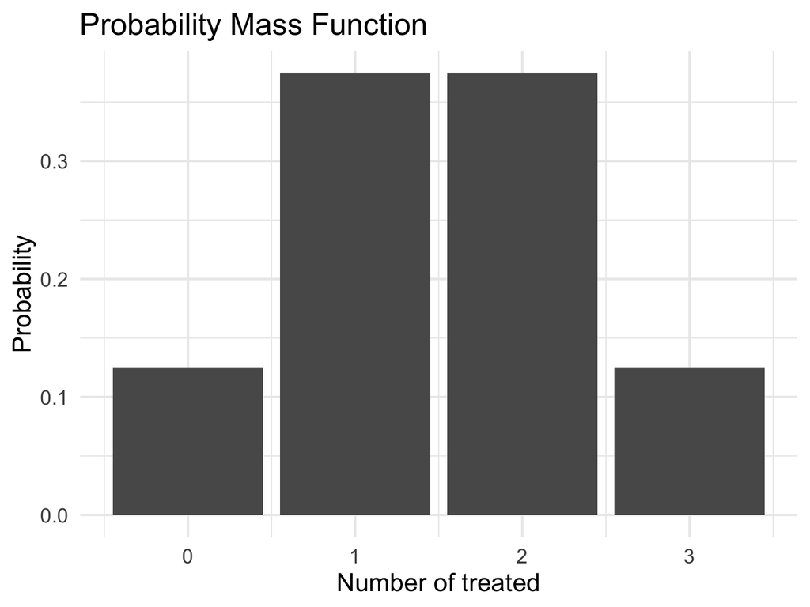

## Probability mass functions

- Probability Mass Function: For a discrete random variable $X$, define the probability mass function $p_X(x)$ as

  $$\begin{eqnarray}
  p(x) & = & P(X = x)
  \end{eqnarray}$$
- Upper vs. lower-case letters
- Note that

  $$\sum_x p_{X}(x) = 1$$

## Probability mass functions

- Can also add probabilities for smaller sets $S$ of possible values of $XS$

  $$\Pr(X \in S) = \sum_{x \in S} p_X (x)$$
- For example, if $X$ is the number of heads obtained in two independent tosses of a fair coin, the probability of at least one head is

  $$\Pr (X > 0) = \sum_{x=1}^2 p_X (x) = \frac{1}{2} + \frac{1}{4} = \frac{3}{4}$$

## Calculate the PMF of a random variable $X$

- For each possible value $x$ of $X$
  1. Collect all possible outcomes that give rise to the event $\{ X=x \}$
  2. Add their probabilities to obtain $p_X (x)$

## Bernoulli random variable

- Suppose $X$ is a random variable, with $X \in \{0, 1\}$ and $P(X = 1) = \pi$. Then we will say that $X$ is **Bernoulli** random variable,

  $$\begin{eqnarray}
  p_X(k) & = & \pi^{k} (1- \pi)^{1 - k} \nonumber
  \end{eqnarray}$$

  for $k \in \{0,1\}$ and $p(k) = 0$ otherwise.
- We will (equivalently) say that

  $$\begin{eqnarray}
  Y & \sim & \text{Bernoulli}(\pi) \nonumber
  \end{eqnarray}$$

## Bernoulli random variable

- Suppose we flip a fair coin and $Y = 1$ if the outcome is Heads.

  $$\begin{eqnarray}
  Y & \sim & \text{Bernoulli}(1/2) \nonumber \\
  p(1) & = & (1/2)^{1} (1- 1/2)^{ 1- 1} = 1/2 \nonumber \\
  p(0) & = & (1/2)^{0} (1- 1/2)^{1 - 0} = (1- 1/2) \nonumber
  \end{eqnarray}$$

## Bernoulli random variable

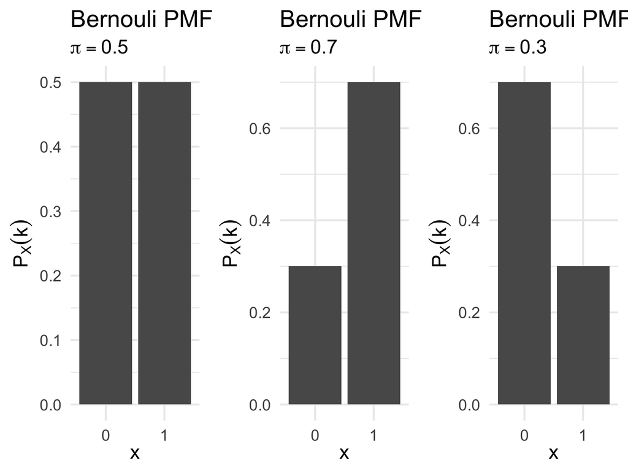

## Binomial random variable

- A model to count the number of successes across $N$ trials
- Suppose $X$ is a random variable that counts the number of successes in $N$ independent and identically distributed Bernoulli trials. Then $X$ is a **Binomial** random variable,

  $$\begin{eqnarray}
  p_X(k) & = & {{N}\choose{k}}\pi^{k} (1- \pi)^{n-k} \nonumber
  \end{eqnarray}$$

  for $k \in \{0, 1, 2, \ldots, N\}$ and $p(k) = 0$ otherwise, and $\binom{N}{k} = \frac{N!}{(N-k)! k!}$. Equivalently,

  $$\begin{eqnarray}
  Y & \sim & \text{Binomial}(N, \pi) \nonumber
  \end{eqnarray}$$

## Binomial random variable

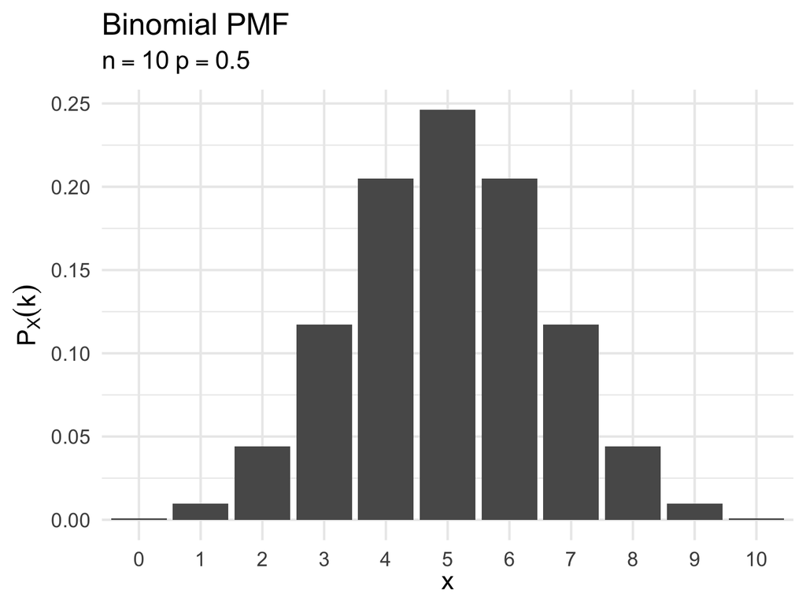

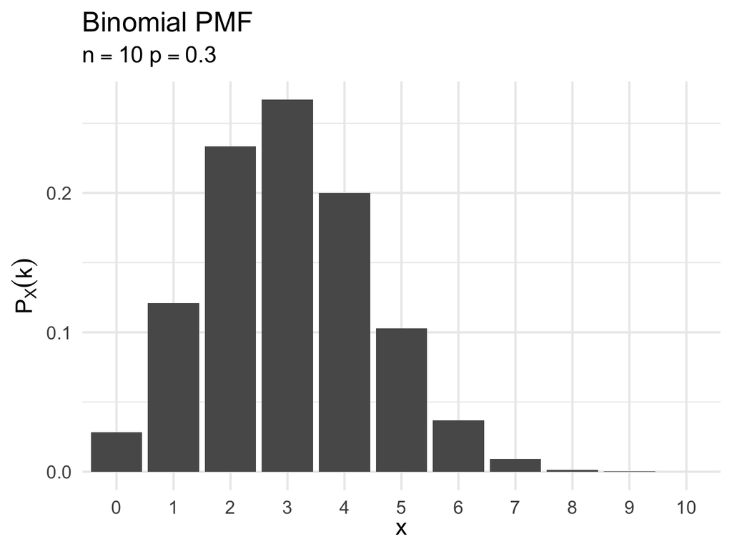

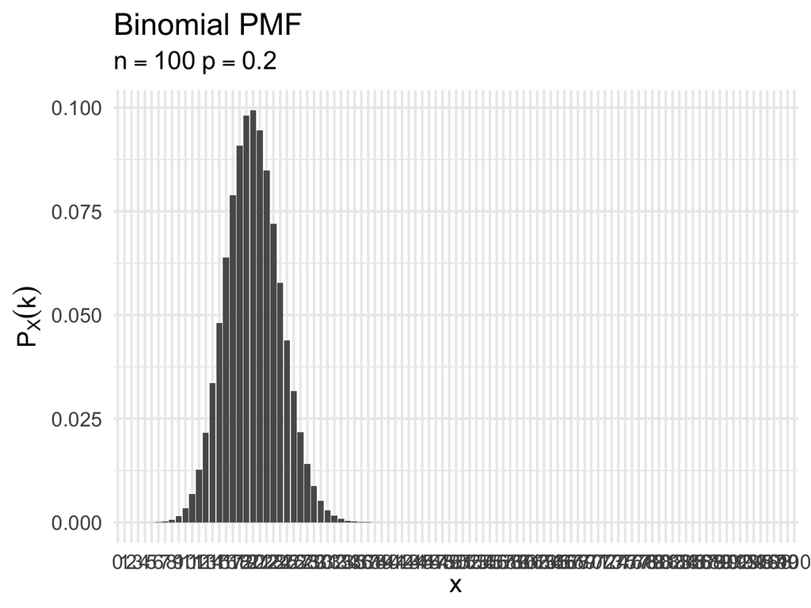

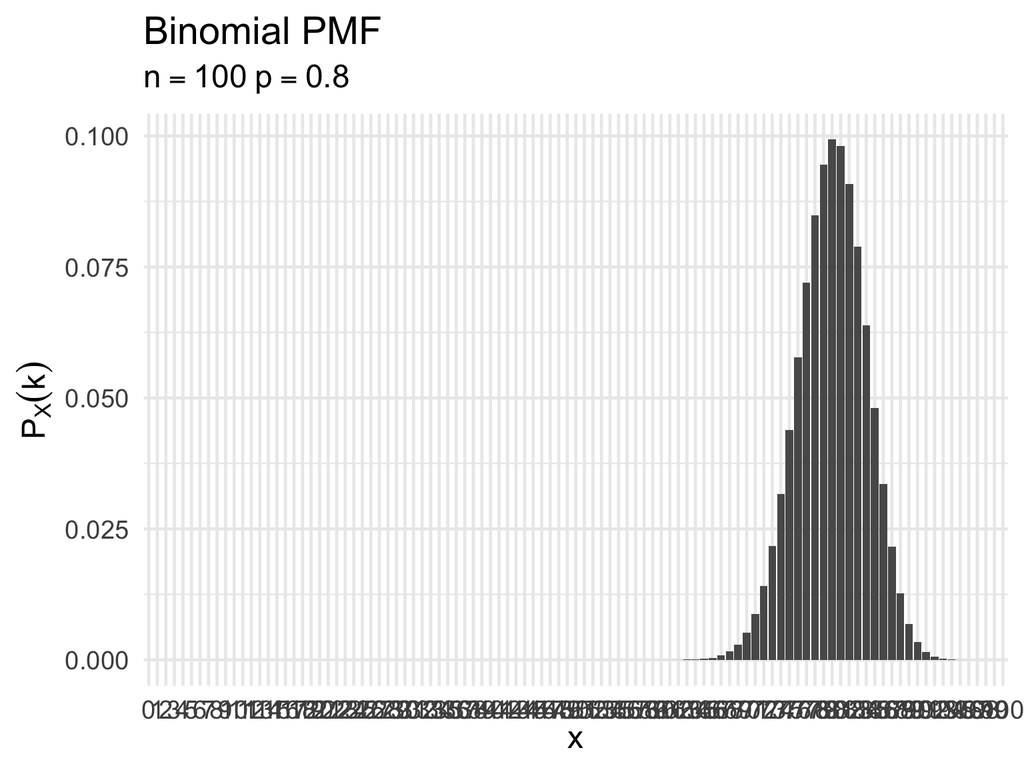

## Binomial random variable

- Recall our experiment example
- $P(T) = P(C) = 1/2$
- $Z =$ number of units assigned to treatment

  $$\begin{eqnarray}
  Z & \sim & \text{Binomial}(1/2)\\
  p(0) & = & {{3}\choose{0}} (1/2)^{0} (1- 1/2)^{3-0} = 1 \times \frac{1}{8}\\
  p(1) & = & {{3}\choose{1}} (1/2)^{1} (1 - 1/2)^{2} = 3 \times \frac{1}{8} \\
  p(2) & = & {{3}\choose{2}} (1/2)^{2} (1- 1/2)^1 = 3 \times \frac{1}{8} \\
  p(3) & = & {{3}\choose{3}} (1/2)^{3} (1 - 1/2)^{0} = 1 \times \frac{1}{8}
  \end{eqnarray}$$

## Geometric random variable

- A model to count the number of trials of a Bernouli outcome before success occurs the first time
- Suppose $X$ is a random variable that counts the number of tosses needed for a head to come up the first time. Its PMF is

  $$\begin{eqnarray}
  p_X(k) & = & (1 - p)^{k-1}p, \quad k = 1, 2, \ldots
  \end{eqnarray}$$
- $(1 - p)^{k-1}p$ is the probability of the sequence consisting of $k-1$ successive trials followed by a head. This is a valid PMF because

  $$\begin{align}
  \sum_{k=1}^{\infty} p_X(k) &= \sum_{k=1}^{\infty} (1 - p)^{k-1}p \\
  &= p \sum_{k=1}^{\infty} (1 - p)^{k-1} \\&
  = p \times \frac{1}{1 - (1-p)} \\
  &= 1
  \end{align}$$

## Geometric random variable

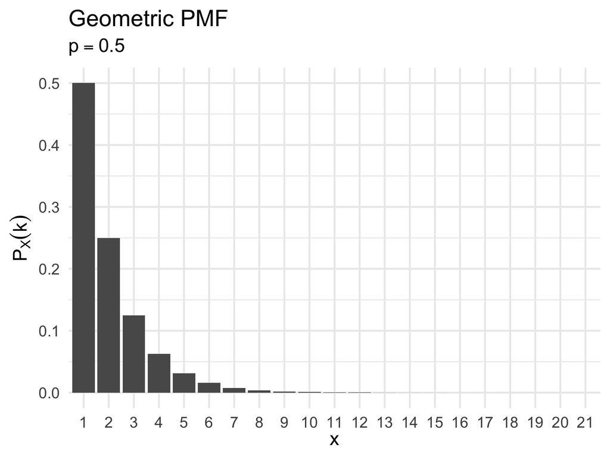

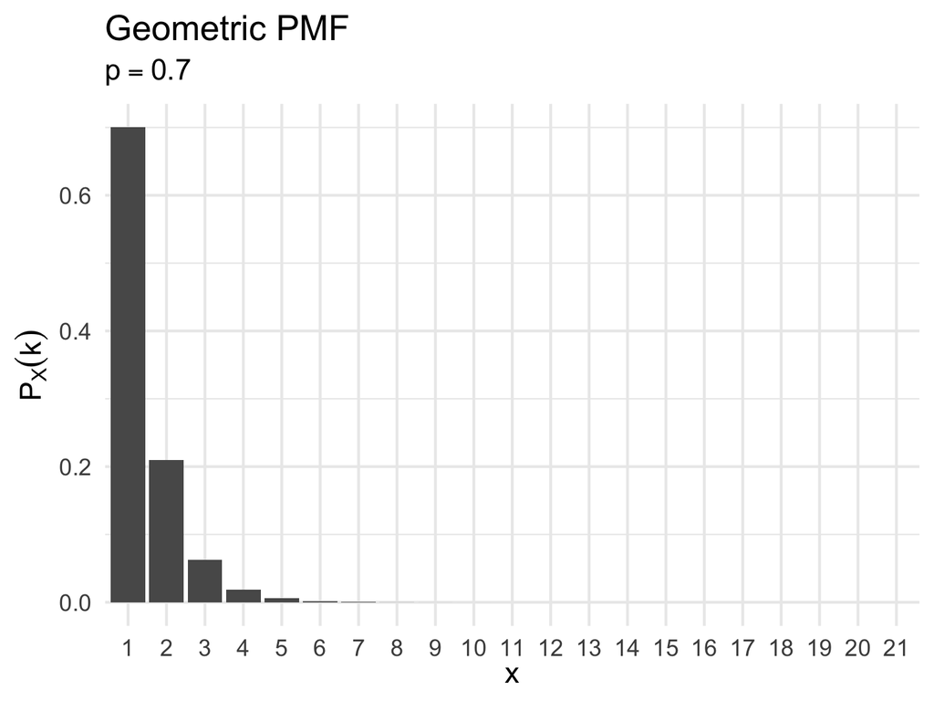

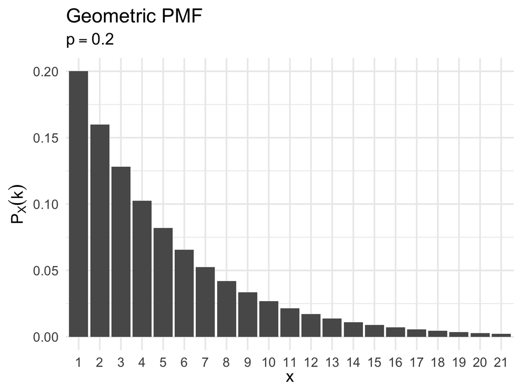

## Poisson random variable

- Often interested in counting number of events that occur:
  - Number of wars started
  - Number of speeches made
  - Number of bribes offered
  - Number of people waiting for license
- Generally referred to as **event counts**

## Poisson random variable

- Suppose $X$ is a random variable that takes on values $X \in \{0, 1, 2, \ldots, \}$ and that $\Pr(X = k) = p_X(k)$ is,

  $$\begin{eqnarray}
  p_X(k) & = & e^{-\lambda} \frac{\lambda^{k}}{k!}, \quad k = 0,1,2,\ldots
  \end{eqnarray}$$

  for $k \in \{0, 1, \ldots, \}$ and $0$ otherwise.
- $X$ follows a **Poisson** distribution with **rate** parameter $\lambda$

  $$\begin{eqnarray}
  X & \sim & \text{Poisson}(\lambda) \nonumber
  \end{eqnarray}$$

## Poisson random variable

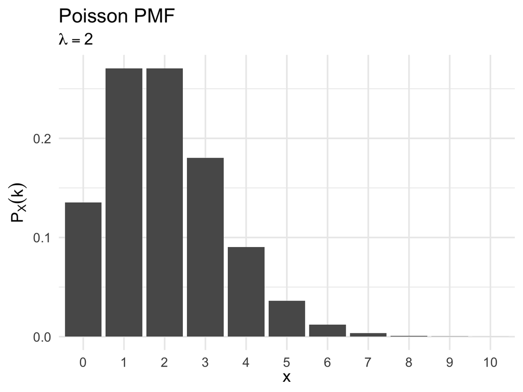

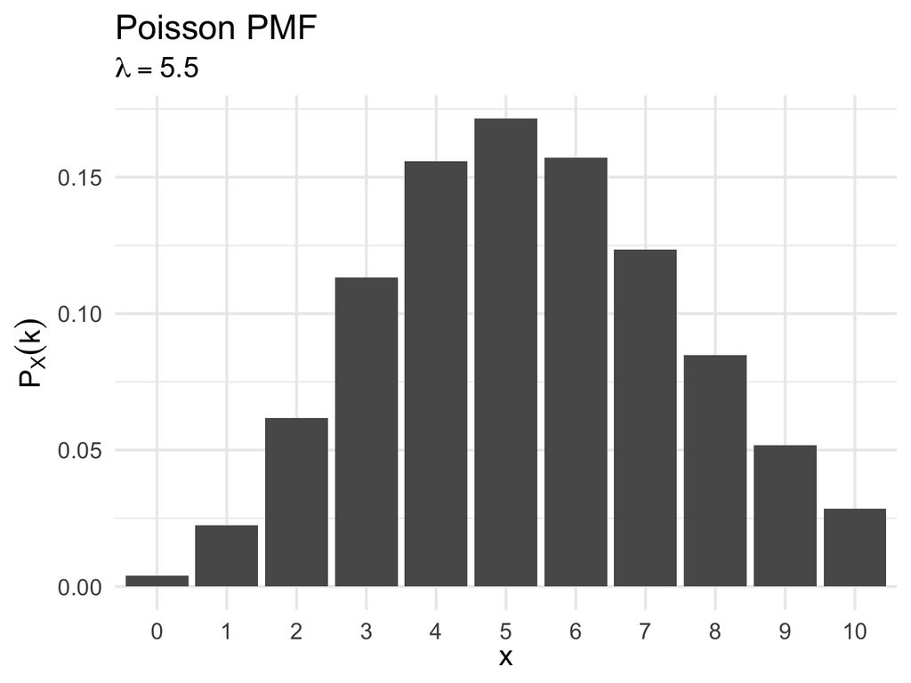

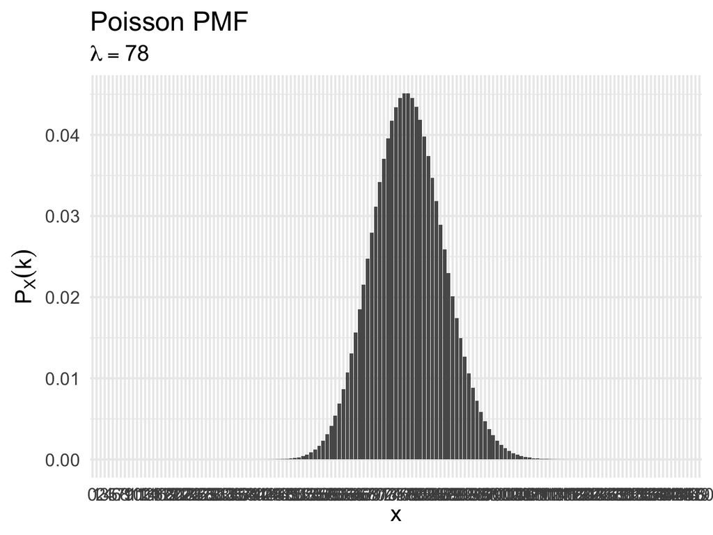

## Poisson random variable

  $$\begin{eqnarray}
  P(X = 10) & = & e^{-\lambda} \frac{5^{10}}{10!}
  \end{eqnarray}$$

## Poisson random variable

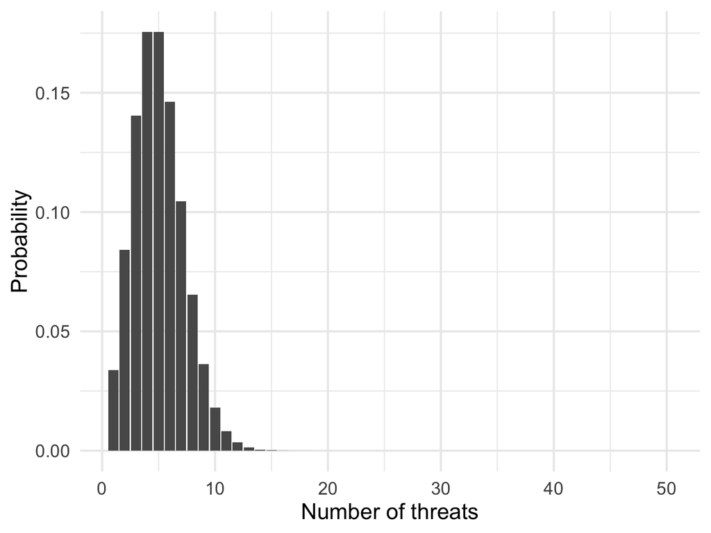

## Approximating a binomial random variable

- The Poisson PMF with parameter $\lambda$ is a good approximation for a binomial PMF with parameters $n$ and $p$

  $$e^{-\lambda} \frac{\lambda^{k}}{k!} \approx {{N}\choose{k}}\pi^{k} (1- \pi)^{n-k}, \quad \text{if } k \ll n$$
  - Provided $\lambda = np$, $n$ is very large, and $p$ is very small
- Sometimes using the Poisson PMF results in simpler models and easier calculations

## Approximating a binomial random variable

- $n = 100$ and $p = 0.01$
- Using the binomial PMF

  $$\frac{100!}{95! 5!} \times 0.01^5 (1 - 0.01)^{95} = 0.00290$$
- Using the Poisson PMF with $\lambda = np = 100 \times 0.01 = 1$

  $$e^{-1} \frac{1}{5!} = 0.00306$$

## Functions of random variables

- Given a random variable $X$, you may wish to create a new random variable $Y$ using transformations of $X$
- Linear transformation $Y = g(X) = aX + b$
- Logarithmic transformation $g(X) = \log(X)$
- If $Y = g(X)$ is a function of a random variable $X$, then $Y$ is also a random variable
- All outcomes in the sample space defined with a numerical value $x$ for $X$ also have a numerical value $y = g(x)$ for $Y$

## Expectation, mean, and variance

- PMF of a random variable $X$ provides several numbers, the probabilities of all possible values of $X$
- Often desirable to summarize this information into a single representative number
- **Expectation** of $X$ - weighted average of the possible values of $X$

## Motivation

> Consider spinning a wheel of fortune many times. At each spin, one of the numbers $m_1, m_2, \ldots, m_n$ comes up with corresponding probability $p_1, p_2, \ldots, p_n$, and this is your monetary reward from that spin. What is the amount of money that you expect to get per spin?

## Expectation

- **Expected value** (known as **expectation** or the **mean**) of a random variable $X$, with PMF $p_X$ is

  $$\begin{eqnarray}
  \E[X] & = & \sum_{x:p(x)>0} x p(x)
  \end{eqnarray}$$

  where $\sum_{x:p(x)>0}$ is all values of $X$ with probability greater than 0

## Example of expected value

- Suppose $X$ is number of units assigned to treatment, in one of our previous example.

  $$\begin{equation}
  X = \left \{ \begin{array} {ll}
  0 \text{ if } (C, C, C) \\
  1 \text{ if } (T, C, C) \text{ or } (C, T, C) \text{ or } (C, C, T) \\
  2 \text{ if } (T, T, C) \text{ or } (T, C, T) \text{ or } (C, T, T) \\
  3 \text{ if } (T, T, T)
  \end{array} \right.
  \end{equation}$$
- What is $E[X]$?

  $$\begin{eqnarray}
  \E[X] & = & 0\times \frac{1}{8} + 1 \times \frac{3}{8} + 2 \times \frac{3}{8} + 3 \times \frac{1}{8} \\
  & = & 1.5
  \end{eqnarray}$$
- Essentially a weighted average, or the average outcome (value in the middle of the range)
- Gives us a measure of **central tendency**

## Moments

- 1st moment: $\E[X^1] = \E[X]$
- 2nd moment: $\E[X^2]$
- $n$th moment: $\E[X^n]$

## Variance

- $\Var(X)$
- Defined as the expected value of the random variable $(X - \E[X])^2$

  $$\begin{align}
  \Var(X) &= \E[(X - \E[X])^2]
  \end{align}$$
  - Since $(X - \E[X])^2$ can only take non-negative values, variance is always non-negative
- Measure of **dispersion** of $X$ around its mean
- We will define the standard deviation of $X$, $\sigma_X = \sqrt{\Var(X)}$

## Calculating variance of a random variable

- We could generate the PMF of the random variable $(X - \E[X])^2$, then calculate the expectation of this function
- Expected value rule for functions of random variables
- Let $X$ be a random variable with PMF $p_X$, and let $g(X)$ be a function of $X$. Then, the expected value of the random variable $g(X)$ is given by

  $$\E[g(X)] = \sum_{x} g(x) p_X(x)$$
- Rewrite our variance formula:

  $$\begin{align}
  \Var(X) &= \E[(X - \E[X])^2] \\
  \Var(X) &= \E[X^2] - \E[X]^2
  \end{align}$$

## Bernoulli variable

- Suppose $Y \sim \text{Bernoulli}(\pi)$

  $$\begin{eqnarray}
  E[Y] & = & 1 \times P(Y = 1) + 0 \times P(Y = 0) \nonumber \\
  & = & \pi + 0 (1 - \pi) \nonumber = \pi \\
  \text{var}(Y) & = & E[Y^2] - E[Y]^2 \nonumber \\
  E[Y^2] & = & 1^{2} P(Y = 1) + 0^{2} P(Y = 0) \nonumber \\
  & = & \pi \nonumber \\
  \text{var}(Y) & = & \pi - \pi^{2} \nonumber \\
  & = & \pi(1 - \pi ) \nonumber
  \end{eqnarray}$$
- $E[Y] = \pi$
- Var$(Y) = \pi(1- \pi)$
- What is the maximum variance?

  $$\begin{eqnarray}
  \text{var}(Y) & = & \pi - \pi^{2} \nonumber \\
  & = & 0.5(1 - 0.5 ) \\
  & = & 0.25
  \end{eqnarray}$$

## Binomial

$$Z = \sum_{i=1}^{N} Y_{i} \text{ where } Y_{i} \sim \text{Bernoulli}(\pi)$$

$$\begin{eqnarray}
E[Z] & = & E[Y_{1} + Y_{2} + Y_{3} + \ldots + Y_{N} ] \\
& = & \sum_{i=1}^{N} E[Y_{i} ] \\
& = & N \pi \\
\text{var}(Z) & = & \sum_{i=1}^{N} \text{var}(Y_{i}) \\
& = & N \pi (1-\pi)
\end{eqnarray}$$

## Decision making using expected values

- Optimizes the choice between several candidate decisions that result in random rewards
- View the expected reward of a decision as its average payoff over a large number of trials
- Choose a decision with maximum expected reward

## Example: going to war

- Suppose country $1$ is engaged in a conflict and can either win or lose
- Define $Y = 1$ if the country wins and $Y = 0$ otherwise
- Then,

  $$\begin{eqnarray}
  Y &\sim & \text{Bernoulli}(\pi)
  \end{eqnarray}$$
- Suppose country $1$ is deciding whether to fight a war
- Engaging in the war will cost the country $c$
- If they win, country $1$ receives $B$
- What is $1$’s expected utility from fighting a war?

  $$\begin{eqnarray}
  E[U(\text{war})] & = & (\text{Utility}|\text{win})\times P(\text{win}) + (\text{Utility}| \text{lose})\times P(\text{lose}) \\
  &= & (B - c) P(Y = 1) + (- c) P(Y = 0 ) \\
  & = & B \times p(Y = 1) - c(P(Y = 1) + P(Y = 0)) \\
  & = & B \times \pi - c
  \end{eqnarray}$$
- Deciding whether to go to war

## Cumulative distribution function

- Defines the the cumulative probability $F_X(x)$ up to the value of $x$
- For a discrete random variable $X$, $F_X$ provides the probability $\Pr (X \leq x)$. For every $x$

  $$F_X(x) = \Pr (X \leq x) = \sum_{k \leq x} p_X(k)$$
- All PMFs have a CDF

## Cumulative distribution function

- $F_X$ is monotonically nodecreasing – if $x \leq y$, then $F_X(x) \leq F_X(y)$
- $F_X(x)$ tends to $0$ as $x \rightarrow -\infty$, and to $1$ as $x \rightarrow \infty$
- $F_X(x)$ is a piecewise constant function of $x$
- If $X$ is discrete and takes integer values, the PMF and the CDF can be obtained from each other by summing or differencing:

  $$F_X(k) = \sum_{i = -\infty}^k p_X(i),$$
  $$p_X(k) = \Pr (X \leq k) - \Pr (X \leq k-1) = F_X(k) - F_X(k-1)$$

  for all integers $k$

## Bernoulli CDF

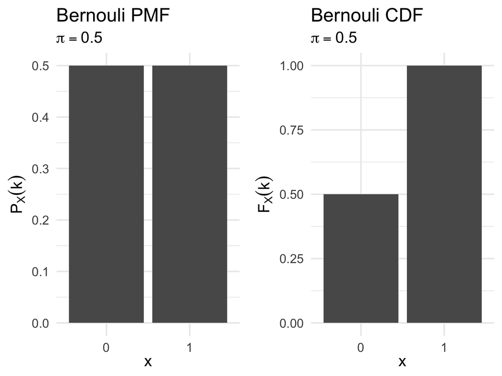

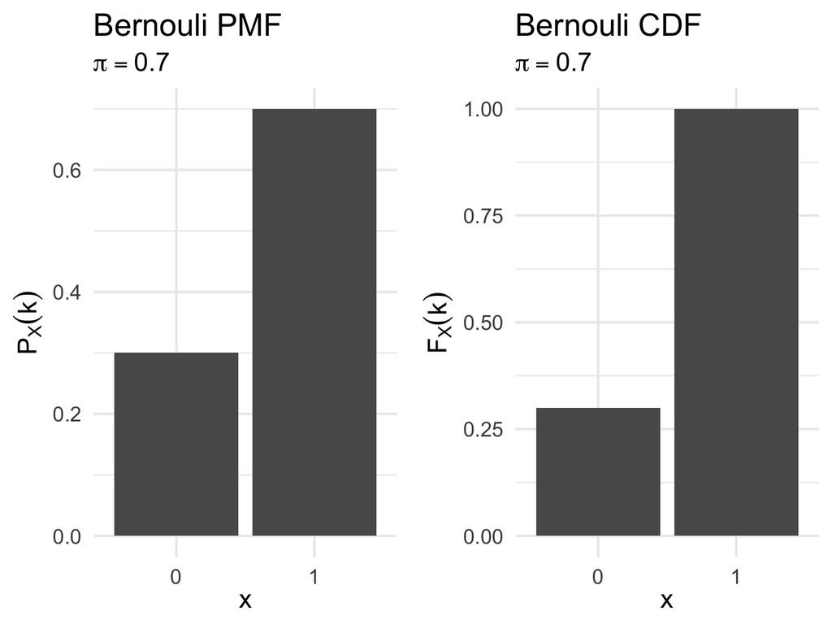

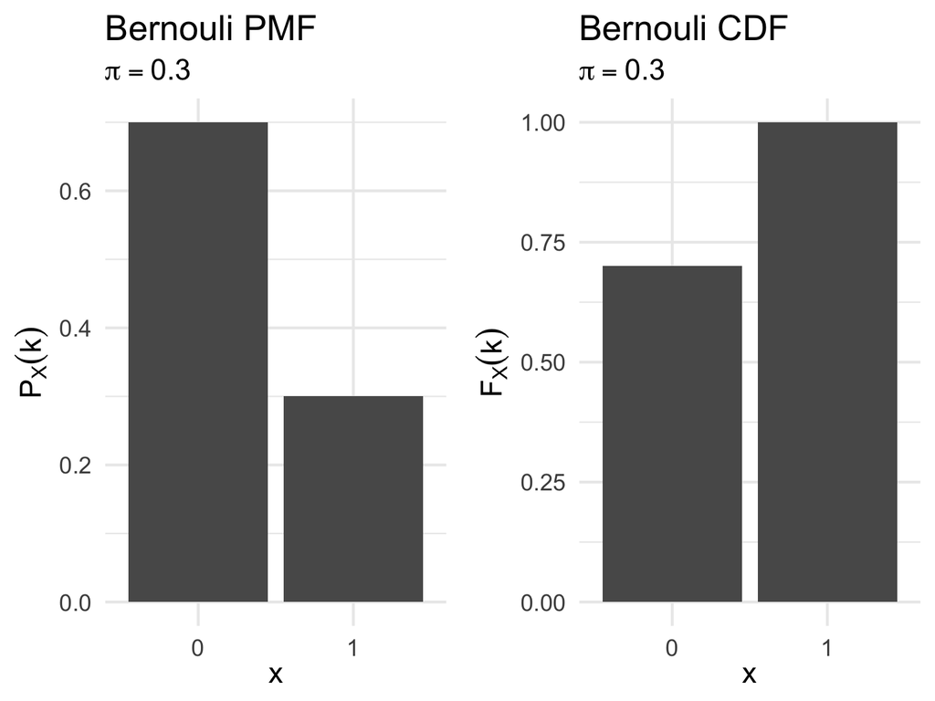

## Binomial CDF

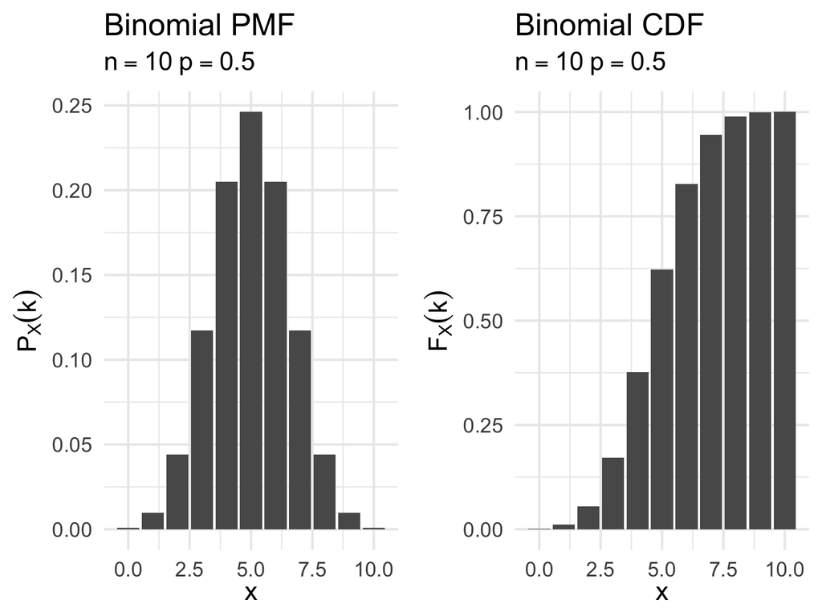

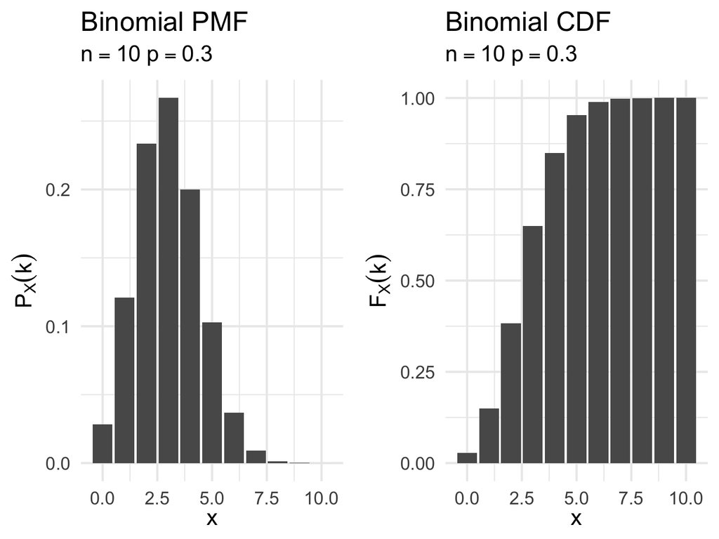

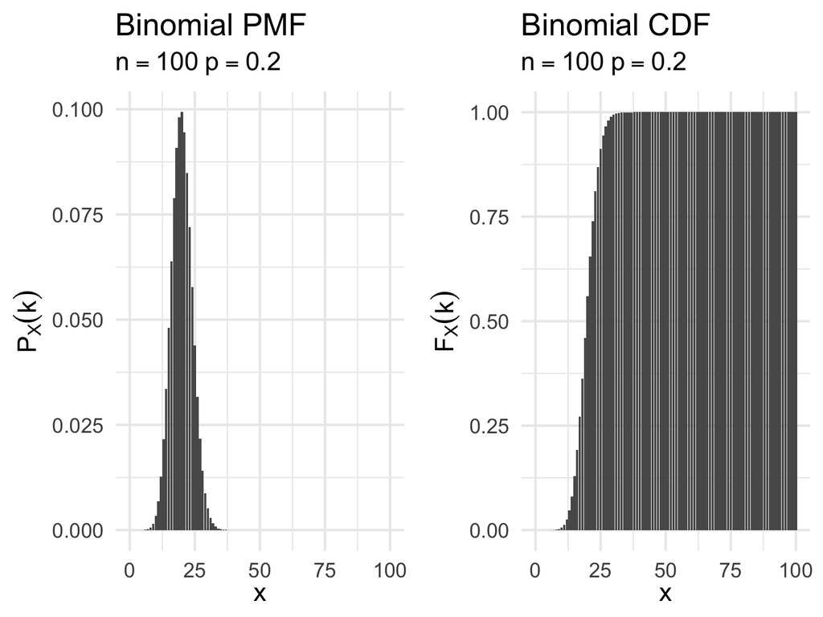

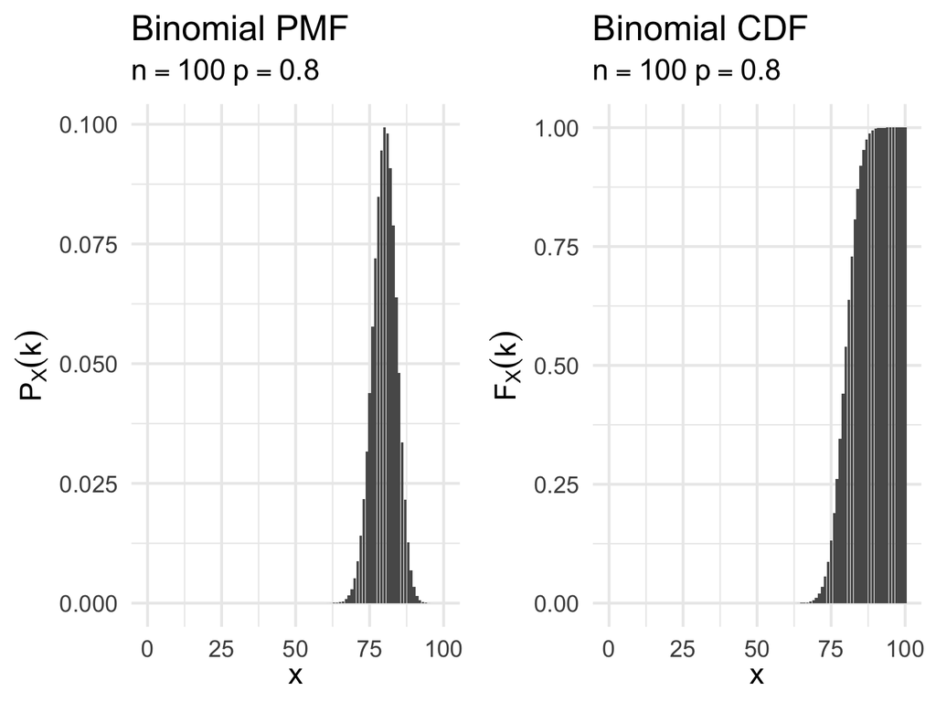

## Geometric CDF

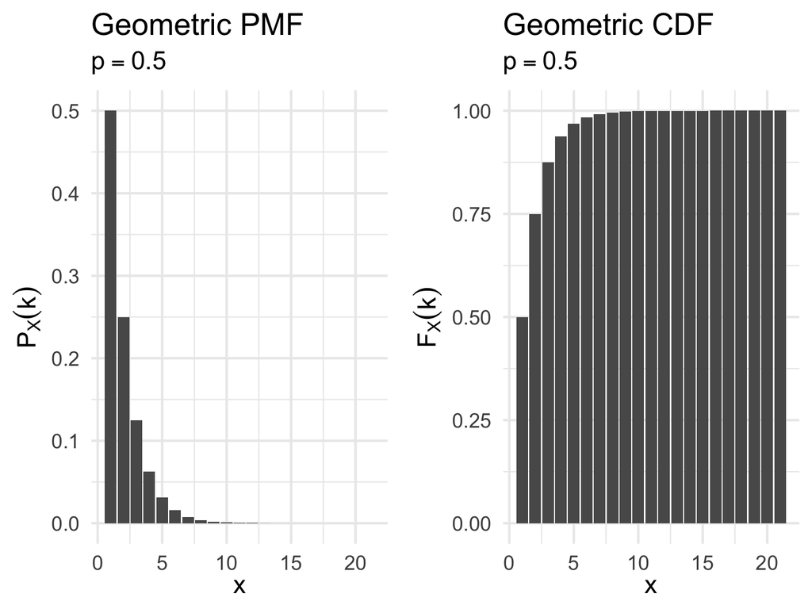

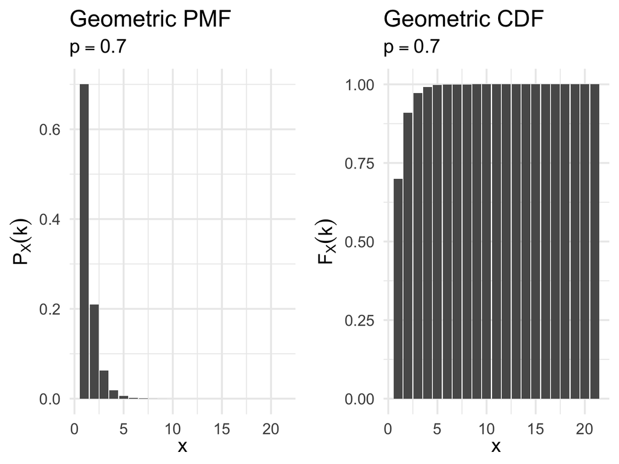

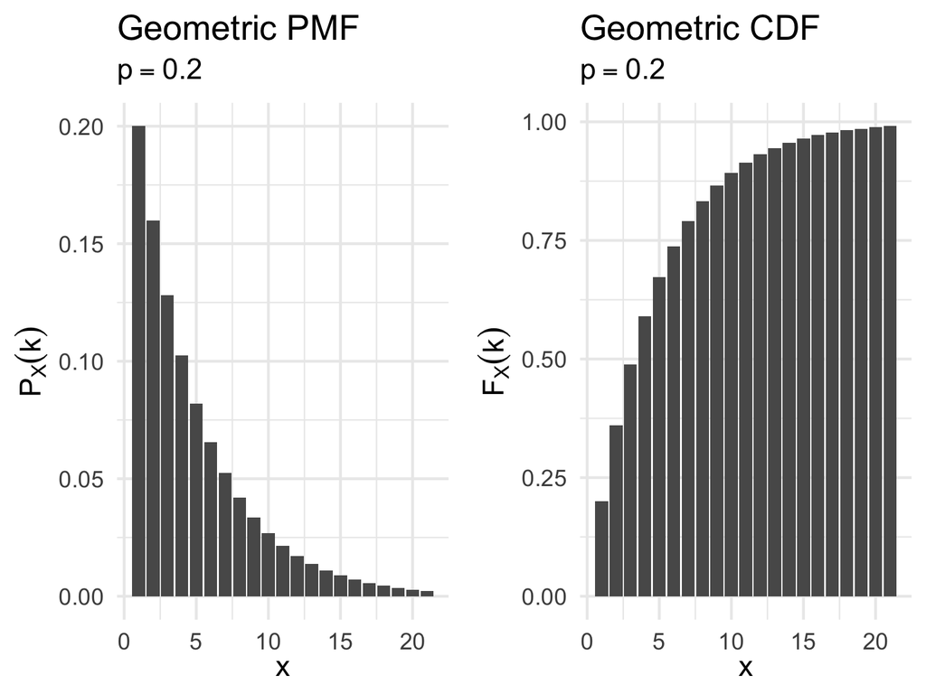

## Poisson CDF

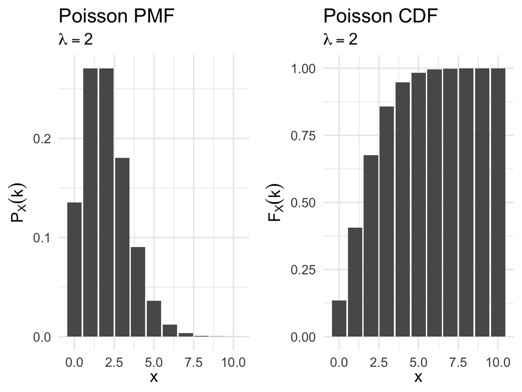

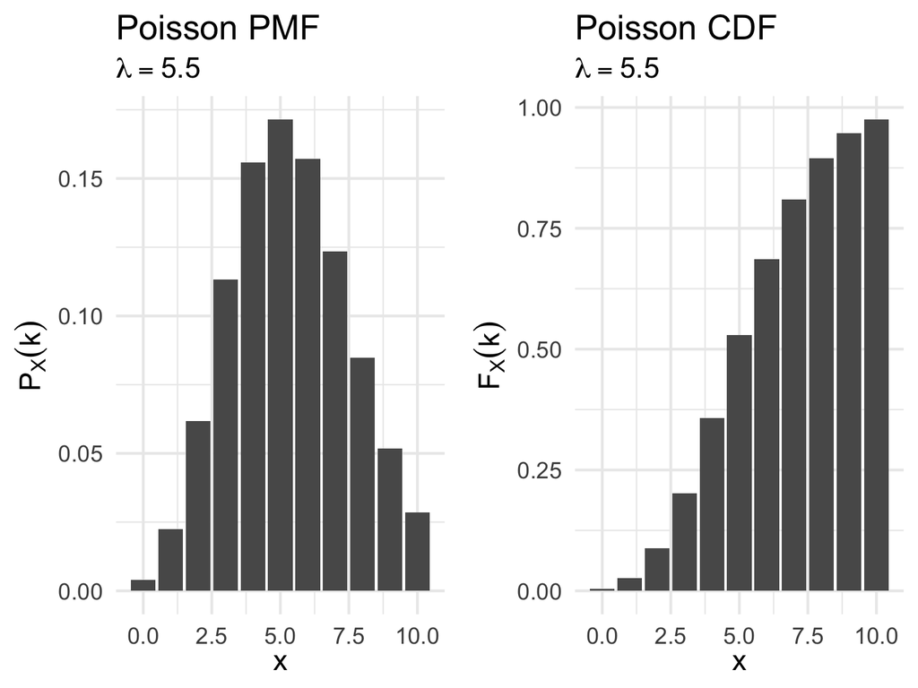

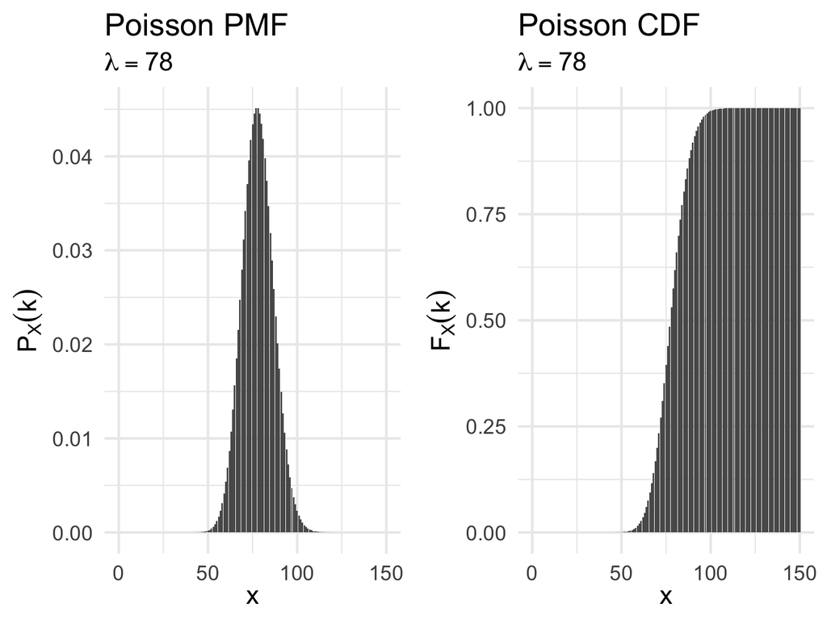